# CARRERA LA LUZ 2022

[figure not shown]

[figure not shown]

[figure not shown]

[figure not shown]

[figure not shown]

[figure not shown]

### **CARRERA LA LUZ 2022**

[figure not shown]

**Carera 10K de la Luz** Evento realizado el pasado 23 de octubre de 2022 en la ciudad de Cali, Colombia por la organización deportiva Juancho Correlón en cooperación con el Hotel Intercontinental con el propósito de brindar ayudas al programa “Compromiso Valle” por los emprendedores y las escuelas de iniciación deportiva de la ciudad, a través de lo recaudado con las inscripciones. Alrededor de casi 3.000 deportistas fueron participes del recorrido que partió desde el hotel Intercontinental para disfrutar de emblemáticos sitios y la belleza de la capital vallecaucana; sitios como **La Calle De La Escopeta, El Museo Arqueológico La Merced, El Bulevar Del Rio, El Puente Ortiz, La Gobernación Del Valle, El Edificio Aristi, La Plazoleta De San Francisco, La Librería Nacional O El Mueso La Tertulia** hicieron parte de los recorridos de 5 o 10 kilómetros hasta finalizar nuevamente en el hotel Intercontinental. [juanchocorrelon.com](https://juanchocorrelon.com/intercontinental-10k-luz-2022/#10k)

### **NUESTRAS CORREDORAS**

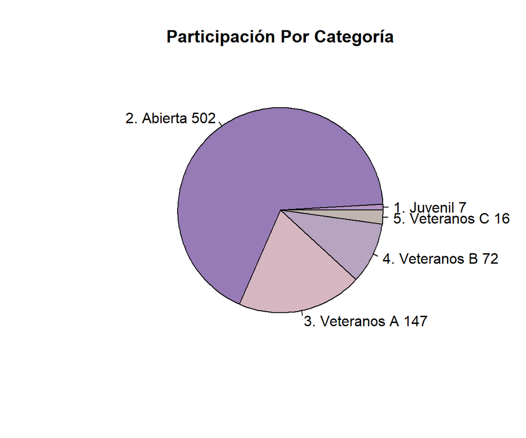

### **PARTICIPACIÓN POR EDADES**

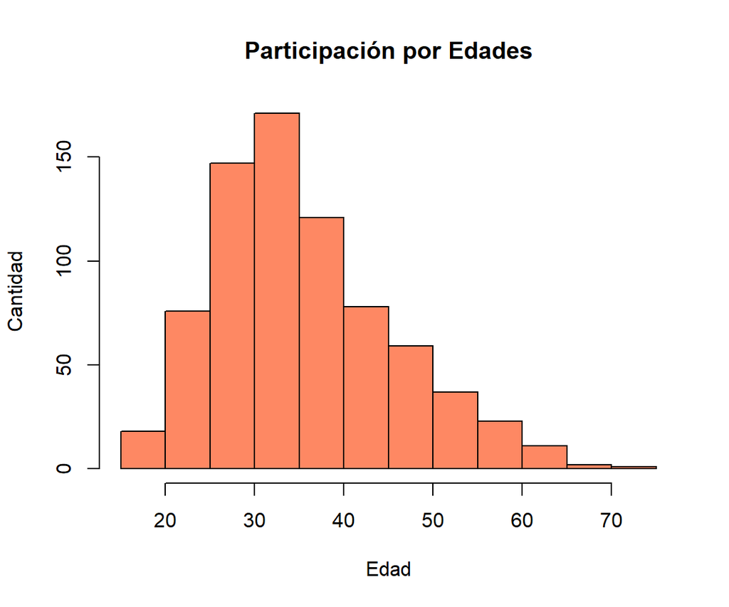

### **TIEMPOS POR CATEGORIA**

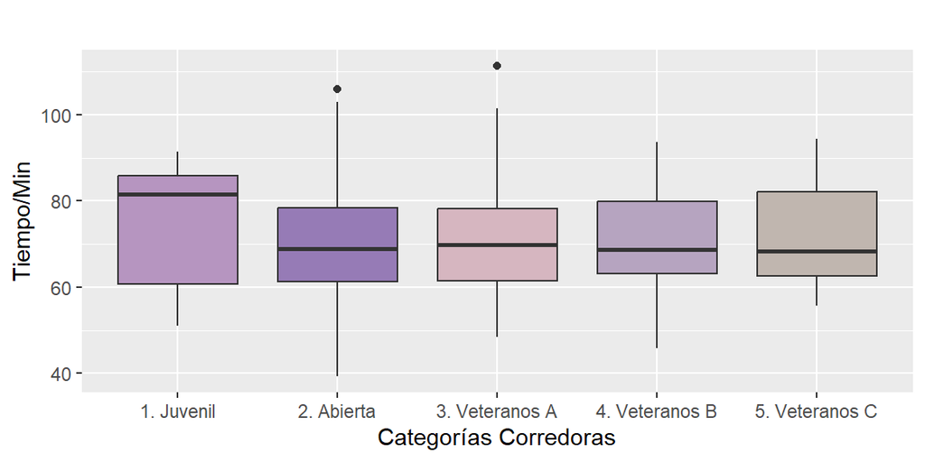

[output not shown]

### **ALGUNAS ESTADÍSTICAS**

**PARTICIPACIÓN DE LAS MUJERES**

```
[1] "38.7%"
```

**VELOCIDAD MÁXIMA MUJERES DE LA CATEGORÍA ABIERTA**

```
[1] "4.28m/s"
```

**ESTADÍSTICAS DE TIEMPOS POR CATEGORÍA**

```
# A tibble: 5 × 5
  categoria      PROMEDIO MEDIANA    SD RANGO
  <chr>             <dbl>   <dbl> <dbl> <dbl>
1 1. Juvenil        4432.   4889   961.  2422
2 2. Abierta        4212.   4134.  705.  3999
3 3. Veteranos A    4235.   4192   714.  3780
4 4. Veteranos B    4222.   4126   661.  2866
5 5. Veteranos C    4334.   4102.  752.  2316
```

### **NUESTROS CORREDORES**

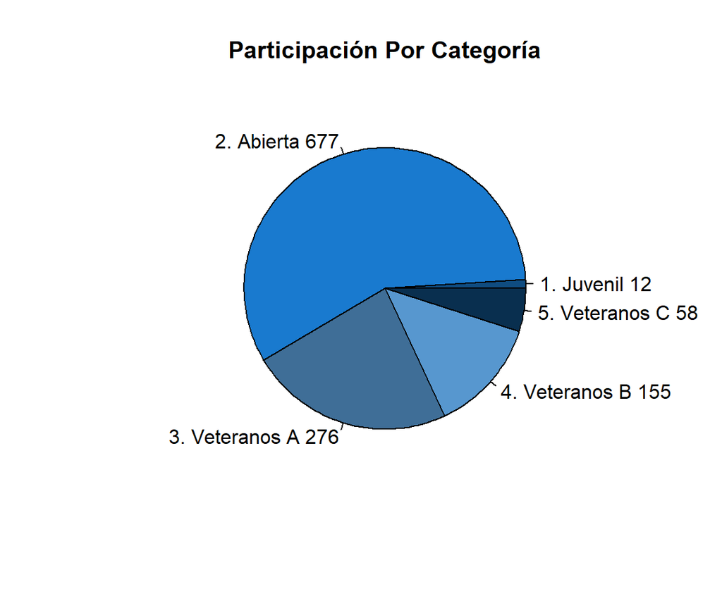

### **PARTICIPACIÓN POR EDADES**

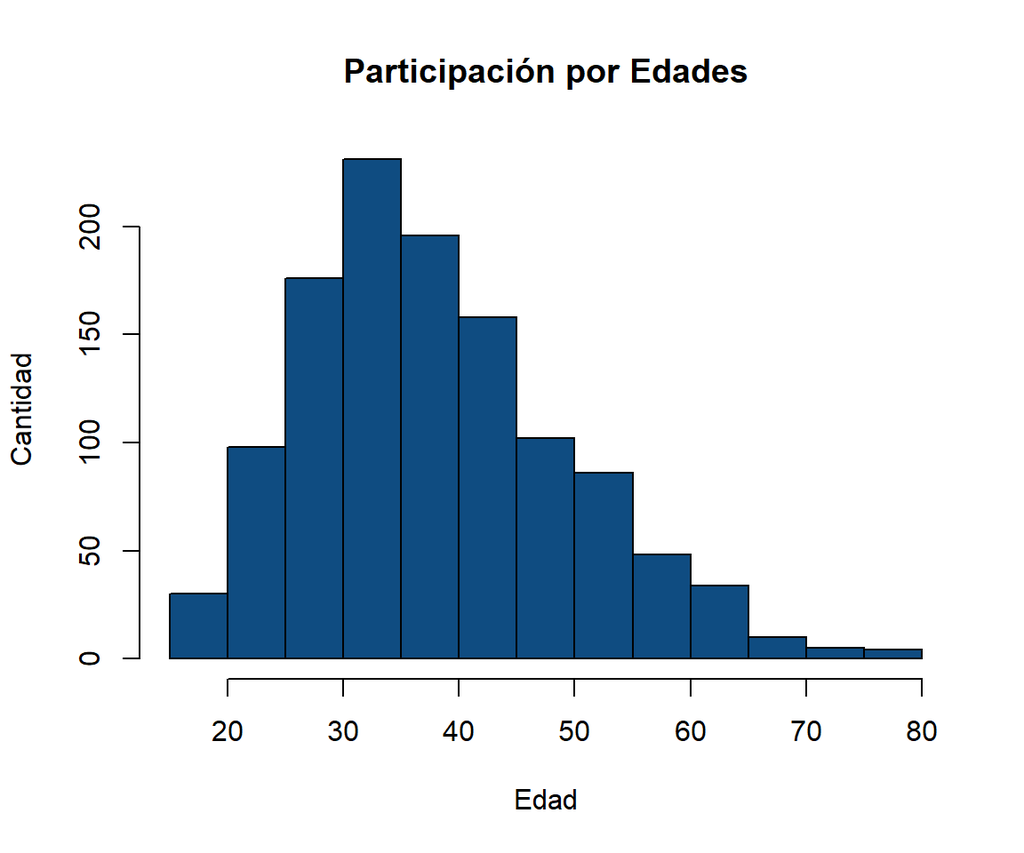

### **TIEMPOS POR CATEGORIA**

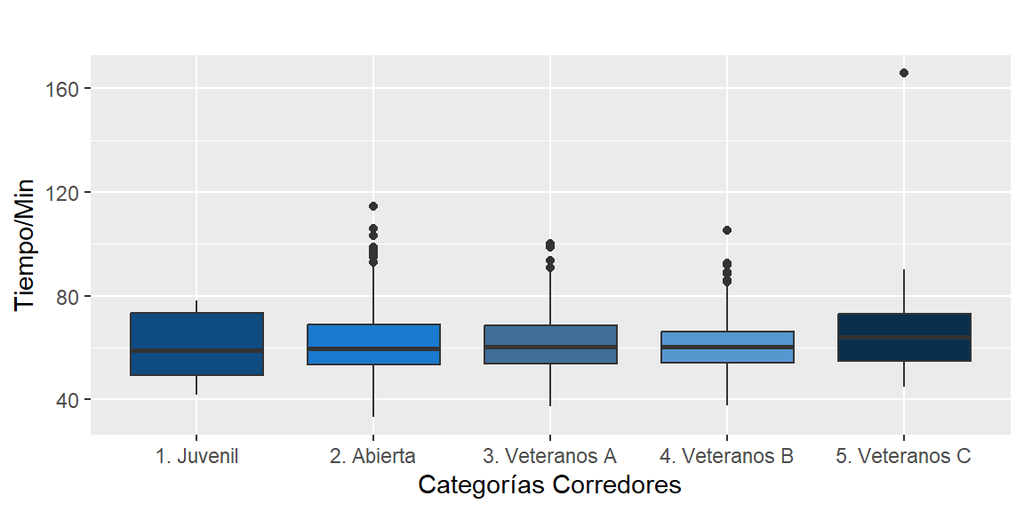

[output not shown]

### **ALGUNAS ESTADÍSTICAS**

**PARTICIPACIÓN DE LAS HOMBRES**

```
[1] "61.3%"
```

**VELOCIDAD MÁXIMA HOMBRES DE LA CATEGORÍA ABIERTA**

```
[1] "5.07m/s"
```

**ESTADÍSTICAS DE TIEMPOS POR CATEGORÍA**

```
# A tibble: 5 × 5
  categoria      PROMEDIO MEDIANA    SD RANGO
  <chr>             <dbl>   <dbl> <dbl> <dbl>
1 1. Juvenil        3586.    3545  815.  2183
2 2. Abierta        3718.    3576  735.  4880
3 3. Veteranos A    3691.    3627  674.  3764
4 4. Veteranos B    3710.    3610  678.  4045
5 5. Veteranos C    3983.    3853 1054.  7265
```

**PROMEDIO DE EDAD MUJERES**

### Juvenil

16.1 años

### Abierta

30.6 años

### Veteranas A

43.7 años

### Veteranas B

53.3 años

### Veteranas C

63.5 años

**PROMEDIO DE EDAD HOMBRES**

### Juvenil

16.2 años

### Abierta

30.9 años

### Veteranos A

43.6 años

### Veteranos B

53.6 años

### Veteranos C

64.9 años